# Lecture 10: Linear regression with R

- Linear regression
  - Simple linear regression
  - Multiple linear regression
- Analysis of variance (ANOVA)

## 10.1 Linear regression

### 10.1.1 Simple linear regression

##### I will use simulated data for this section. This will help you understand model assumptions. For this time, please try to understand the data generating process.

##### Some background information.

- I spent a few weeks shopping for a diamond ring.
- I browsed many diamonds with G or H color, VVS1 or VVS2 clarity, excellent cut and between 1.00 and 1.50 carats.
  - I found out that the prices of such diamonds were predictable.
- As a statistician, I was thinking of fitting a linear regression to explore the relationship between the 4C's and the price.
  - So that I could pick the one that was significantly cheaper than it should be according to my statistical model.
  - Therefore having the lowest price-quality ratio.
  - I was too young and naive.
- **The most important thing is price! Which is mainly driven by the second important thing - carat!**
- But still the other 3C's and some other minor factors may affect the price by a smaller margin.
  - Sometimes higher, sometimes lower, **no effect on average**.

#### The assumptions on the small effects are,

- Normal distribution.
  - This small deviation is **normally distributed with mean 0.**
- Constant variance.
  - This small deviation is the same for all diamonds, **regardless of carat**.

#### Therefore the data follows,

$$ price_i = \beta_0 + \beta_1 \times carat_i + \epsilon_i $$

where $\epsilon_i \sim_{i.i.d} Normal(0, \sigma^2)$ is the small deviation, which is sometimes called the noise.

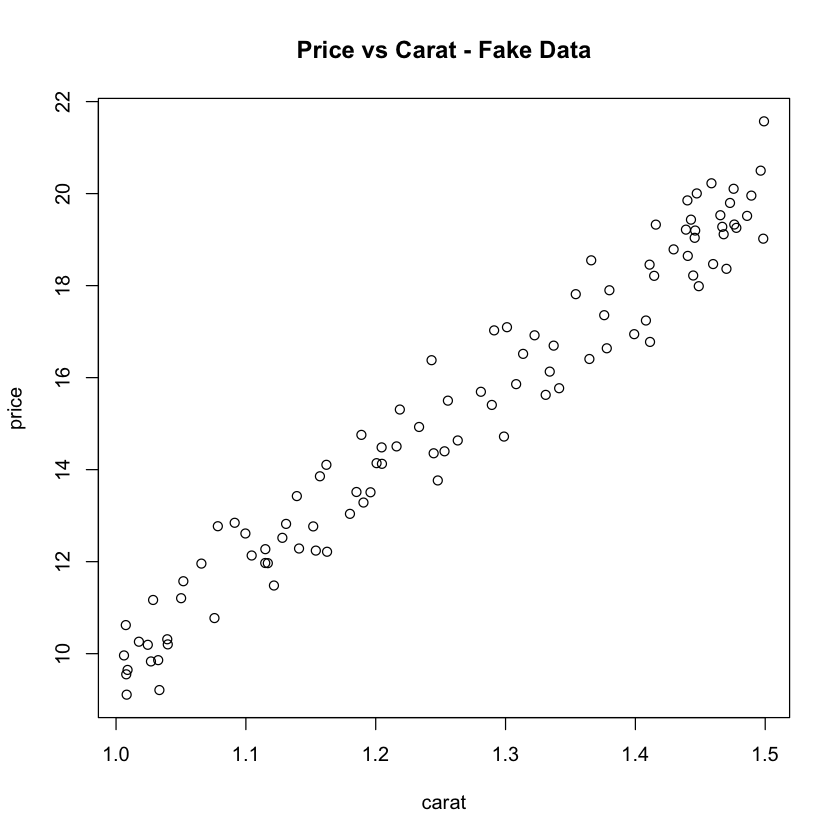

```r
# Set seed for reproducibility
set.seed(613)

# 100 diamond rings ranging from 1 to 1.5 carats
n <- 100
carat <- runif(n = n, min = 1, max = 1.5)
color <- as.factor(sample(c("G", "H"), size = n, replace = TRUE))

# Normally distributed deviation from my perfect model caused by other factors
error <- rnorm(n = n, mean = 0, sd = 0.5)

# On average:
# 1.00 carat: $10k;
# ................;
# 1.50 carat: $20k;

# Comparing to the average price.
# G color increases the price by 500
# H color decreases the price by 500
price <- -10 + 20 * carat + error + ifelse(color=="G", 0.5, -0.5)

plot(x = carat, y = price, main = "Price vs Carat - Fake Data")
```

#### The model is,

$$ \hat{price}_i = \hat{\beta}_0 + \hat{\beta}_1 \times carat_i $$

The goal is to de-noise and capture the association - find a straight line that best describes the association. How?

Consider the residual ($e_i$), which is the deviation of the observed data from the best fit line.

$$ e_i = price_i - \hat{price_i} = price_i - \hat{\beta}_0 - \hat{\beta}_1 \times carat_i $$

It makes sense to find a line that minimizes the sum of the residuals squared $ \sum_{i=1}^n e_i^2 $.

Why squared?

#### The math is,

in EPIB 621.

There is closed-form solution to linear model coefficients - nice.

#### Fit a linear model of the data considering only carat

```r
fit1 <- lm(price~carat); fit1
```

```
Call:
lm(formula = price ~ carat)

Coefficients:
(Intercept)        carat
     -10.56        20.41
```

```r
# If our data is a data.frame, note the data argument.
diamond <- data.frame(Price = price, Carat = carat, Color = color)
head(diamond)
aggregate(Price~Color, data = diamond, mean)
table(diamond$Color)
```

| Price | Carat | Color |
| --- | --- | --- |
| 19.95654 | 1.489319 | G |
| 19.25550 | 1.477755 | G |
| 11.57460 | 1.051832 | G |
| 16.77606 | 1.411278 | H |
| 12.21557 | 1.162526 | H |
| 19.53011 | 1.465442 | G |

| Color | Price |
| --- | --- |
| G | 15.96176 |
| H | 14.64663 |

```
 G  H
45 55
```

```r
fit1 <- lm(Price~Carat, data = diamond)
summary(fit1)
```

```
Call:
lm(formula = Price ~ Carat, data = diamond)

Residuals:
     Min       1Q   Median       3Q      Max
-1.46165 -0.49393 -0.01744  0.50356  1.57524

Coefficients:
            Estimate Std. Error t value Pr(>|t|)
(Intercept) -10.5642     0.5731  -18.43   <2e-16 ***
Carat        20.4084     0.4498   45.38   <2e-16 ***
---
Signif. codes:  0 ‘***’ 0.001 ‘**’ 0.01 ‘*’ 0.05 ‘.’ 0.1 ‘ ’ 1

Residual standard error: 0.7164 on 98 degrees of freedom
Multiple R-squared:  0.9546,	Adjusted R-squared:  0.9541
F-statistic:  2059 on 1 and 98 DF,  p-value: < 2.2e-16
```

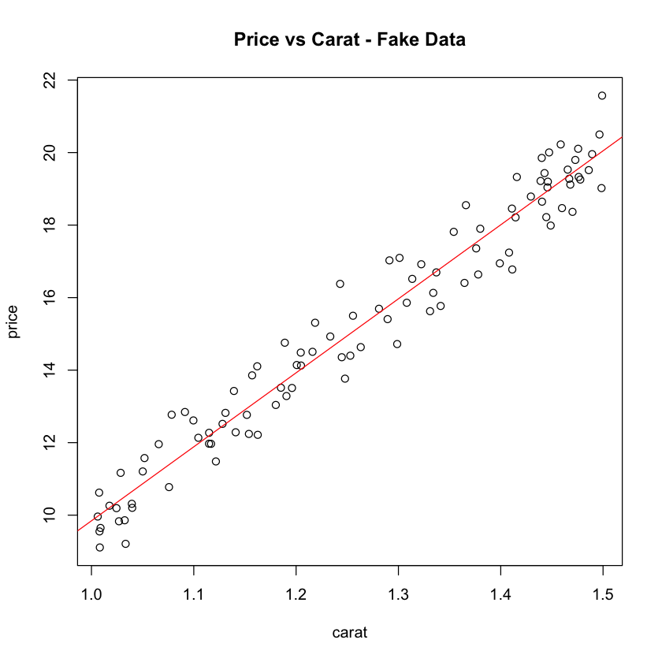

```r
plot(x = carat, y = price, main = "Price vs Carat - Fake Data")
# Draw the best fit line from our linear model.
abline(fit1, col = "red")
```

```r
# Explore the structure of fit1 and summary(fit1) to see how to extract values.
# str(fit1)
# str(summary(fit1))
```

#### Interpretation of the coefficients along with confidence intervals of the estimated coefficients.

```r
summary(fit1)$coefficients
```

|  | Estimate | Std. Error | t value | Pr(>\|t\|) |
| --- | --- | --- | --- | --- |
| (Intercept) | -10.56419 | 0.5731325 | -18.43237 | 1.284998e-33 |
| Carat | 20.40839 | 0.4497598 | 45.37620 | 1.338250e-67 |

```r
# Confidence intervals - default is 95%
confint(fit1, level = 0.95)
```

|  | 2.5 % | 97.5 % |
| --- | --- | --- |
| (Intercept) | -11.70155 | -9.426825 |
| Carat | 19.51585 | 21.300922 |

#### Check model fit and assumptions using plots

- First plot checks the constant variance assumpation
- Second plot checks the normality assumption

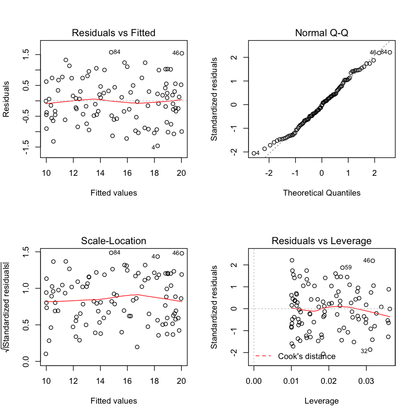

```r
par(mfrow = c(2,2))
plot(fit1)
```

### 10.1.2 Multiple linear regression

Simply more than one $x$'s.

#### Fit a linear model considering both carat and color

```r
fit2 <- lm(Price~Carat+Color, data = diamond)
summary(fit2)
```

```
Call:
lm(formula = Price ~ Carat + Color, data = diamond)

Residuals:
     Min       1Q   Median       3Q      Max
-1.01859 -0.41196 -0.02829  0.39020  1.16421

Coefficients:
            Estimate Std. Error t value Pr(>|t|)
(Intercept)  -9.8203     0.4108  -23.90   <2e-16 ***
Carat        20.2625     0.3174   63.84   <2e-16 ***
ColorH       -1.0172     0.1016  -10.01   <2e-16 ***
---
Signif. codes:  0 ‘***’ 0.001 ‘**’ 0.01 ‘*’ 0.05 ‘.’ 0.1 ‘ ’ 1

Residual standard error: 0.505 on 97 degrees of freedom
Multiple R-squared:  0.9777,	Adjusted R-squared:  0.9772
F-statistic:  2122 on 2 and 97 DF,  p-value: < 2.2e-16
```

```r
# Adjust for all other variables in the dataset other than Price.
# lm(Price~., data = diamond)

# Adjust for interaction terms - effect measure modification EPIB 603.
# lm(Price~ Carat + Color + Carat:Color, data = diamond)
# Equivalent to
# lm(Price~ Carat * Color, data = diamond)
```

#### Prediction using the regression model

Predict the average price of an 1.22 carat diamond with G color - confidence interval.

```r
predict(fit2, newdata = data.frame(Carat=1.22, Color="G"), interval = "confidence")
```

|  | fit | lwr | upr |
| --- | --- | --- | --- |
| 1 | 14.89996 | 14.74694 | 15.05298 |

Predict the price of an 1.22 carat diamond with G color - prediction interval.

```r
predict(fit2, newdata = data.frame(Carat=1.22, Color="G"), interval = "prediction")
```

|  | fit | lwr | upr |
| --- | --- | --- | --- |
| 1 | 14.89996 | 13.88604 | 15.91388 |

#### Draw confidence interval and prediction interval for simple linear regression (fit1)

Hard to visualize when there are more than one $x$'s.

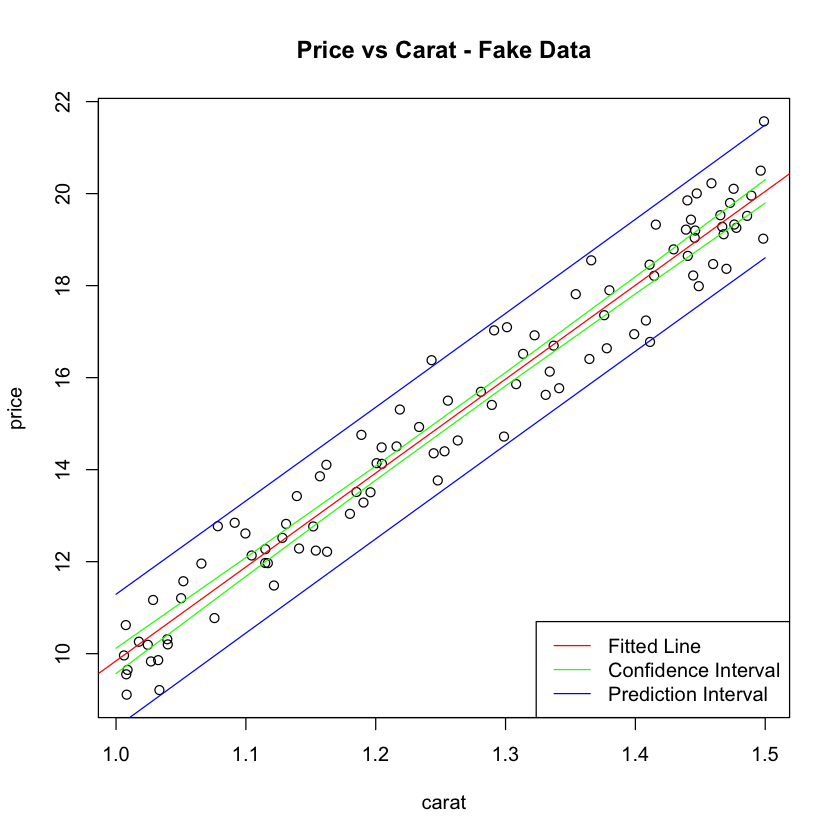

```r
CI <- predict(fit1, newdata = data.frame(Carat=seq(1,1.5,0.1)), interval = "confidence")
PI <- predict(fit1, newdata = data.frame(Carat=seq(1,1.5,0.1)), interval = "prediction")
plot(x = carat, y = price, main = "Price vs Carat - Fake Data")
# Draw the best fit line from our linear model.
abline(fit1, col = "red")
lines(x = seq(1,1.5,0.1), y = CI[,2], col = "green")
lines(x = seq(1,1.5,0.1), y = CI[,3], col = "green")

lines(x = seq(1,1.5,0.1), y = PI[,2], col = "blue")
lines(x = seq(1,1.5,0.1), y = PI[,3], col = "blue")

legend("bottomright", col = c("red", "green", "blue"), lty = c(1,1,1),
       legend = c("Fitted Line", "Confidence Interval", "Prediction Interval"))
```

##### Programming-wise, simple linear regression and multiple linear regressions are the same.

## 10.2 Analysis of Variance

### 10.2.1 ANOVA without regression

Recall that we could use t-test to test whether two treatment effects are significantly different.

```r
price.G <- subset(x = diamond, Color == "G")$Price
price.H <- subset(x = diamond, Color == "H")$Price
mu.G <- mean(price.G)
mu.H <- mean(price.H)
mu.tot <- mean(diamond$Price)
data.frame(G=mu.G, H=mu.H, Total=mu.tot)
```

| G | H | Total |
| --- | --- | --- |
| 15.96176 | 14.64663 | 15.23844 |

```r
t.test(price.G, price.H)
```

```
	Welch Two Sample t-test

data:  price.G and price.H
t = 1.995, df = 95.678, p-value = 0.04888
alternative hypothesis: true difference in means is not equal to 0
95 percent confidence interval:
 0.00656516 2.62370032
sample estimates:
mean of x mean of y
 15.96176  14.64663
```

##### This is a direct comparison of the two means.

- G color is significantly more expensive than H color.

##### We can also use the variance to test whether two groups are different. How?

- Decompose the total variation in the dataset into within group variation and between group variation.
- Think of the test as: if too much of the total variation comes from the between group variation, we believe that the two groups are different.

```r
myanova <- aov(Price~Color, data = diamond)
summary(myanova)
```

```
            Df Sum Sq Mean Sq F value Pr(>F)
Color        1   42.8   42.81   3.942 0.0499 *
Residuals   98 1064.1   10.86
---
Signif. codes:  0 ‘***’ 0.001 ‘**’ 0.01 ‘*’ 0.05 ‘.’ 0.1 ‘ ’ 1
```

##### The null hypothesis that the two groups are equal is rejected.

```r
# Reproduce the test result from scratch
# ss means sum of squares
ss.within = sum((price.G-mu.G)^2) + sum((price.H-mu.H)^2)
ss.between = (mu.G-mu.tot)^2 * 45 + (mu.H-mu.tot)^2 * 55
ss.total = var(diamond$Price) * (n-1)
data.frame(Within = ss.within, Between = ss.between, Total = ss.total)
```

| Within | Between | Total |
| --- | --- | --- |
| 1064.131 | 42.80696 | 1106.938 |

### 10.2.2 ANOVA in regression

- We saw that the calculations involve within group variance calculation for each group.
- We had 2 groups. What if we had more?
- What if we had many more? e.g. carat in the first dataset - a continuous variable.

```r
head(diamond$Carat, 20)
```

1. 1.48931883147452

2. 1.4777549788123

3. 1.05183249094989

4. 1.41127772070467

5. 1.16252580692526

6. 1.46544234571047

7. 1.28101023298223

8. 1.44567985611502

9. 1.09136897884309

10. 1.21604923321865

11. 1.30815492232796

12. 1.18015707843006

13. 1.20065634301864

14. 1.11689501185901

15. 1.29879072017502

16. 1.35407601017505

17. 1.11498201265931

18. 1.13925164530519

19. 1.01760521158576

20. 1.03983685944695

#### The logic: fit a linear model, decompose the total variation into model variation (between group) and residual variation (within group).

```r
anova(fit1)
```

|  | Df | Sum Sq | Mean Sq | F value | Pr(>F) |
| --- | --- | --- | --- | --- | --- |
| Carat | 1 | 1056.64594 | 1056.6459386 | 2058.999 | 1.33825e-67 |
| Residuals | 98 | 50.29205 | 0.5131842 | NA | NA |

```r
anova(fit2)
```

|  | Df | Sum Sq | Mean Sq | F value | Pr(>F) |
| --- | --- | --- | --- | --- | --- |
| Carat | 1 | 1056.64594 | 1056.6459386 | 4143.1303 | 2.202395e-81 |
| Color | 1 | 25.55360 | 25.5535951 | 100.1962 | 1.276915e-16 |
| Residuals | 97 | 24.73846 | 0.2550357 | NA | NA |

#### Compare two regression models.

- Our fit1 is a reduced version of fit2
- Test whether the deletion of "Color" significantly affect model fit.
  - Rejected: use full model.

```r
anova(fit1, fit2)
```

| Res.Df | RSS | Df | Sum of Sq | F | Pr(>F) |
| --- | --- | --- | --- | --- | --- |
| 98 | 50.29205 | NA | NA | NA | NA |
| 97 | 24.73846 | 1 | 25.5536 | 100.1962 | 1.276915e-16 |

## Assignment 2